철학 학술 동향 브리핑 리포트

# 현대 철학 지형 속의 칼 바르트 연구 동향 리포트

인식론, 행위주의 존재론, 그리고 탈근대 대륙철학의 교차 지점에 관한 실증 서지 분석

데이터 소스: PhilPapers, SEP, Semantic Scholar, Google Scholar, IxTheo(튀빙겐 대학교) 기준 연도: 1980–2026 철학적 바르트 비판적 실재론 삼위일체 존재론 IxTheo 실증 색인

핵심 요약(Executive Summary)

칼 바르트(Karl Barth, 1886–1968)는 더 이상 신학의 영역에만 머무르는 인물이 아니다. 현대 철학계는 바르트의 저작에서 **비판적 실재론**(Critical Realism), **마르부르크 신칸트학파의 선험적 한계 수용**, **주체로의 전회에 대한 해체**(Critique of the Turn to the Subject), **행위주의적 존재론**(Actualist Ontology), **헤겔 변증법 비판**, 그리고 **언어와 반복**(Repetition)에 관한 독창적인 철학적 통찰을 발굴하여, 현대 존재론과 인식론의 최전선에서 능동적인 대화 상대로 다루고 있다.

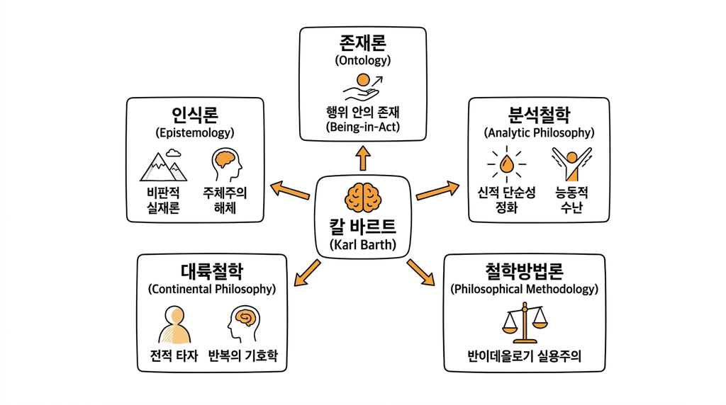

그림 1. 현대 철학 지형 속 칼 바르트 연구의 5대 핵심 개념 맵 (인식론, 존재론, 분석철학, 대륙철학, 철학방법론)

## 1. 철학계의 바르트 연구 5대 거시 경향성 개관

현대 철학계에서 전개되는 바르트 연구의 전체 지형도는 크게 다음과 같은 **다섯 가지 핵심 전회**(Five Major Turns)로 수렴된다.

전회 1 · 인식론

근대 주체주의 해체와 탈주체적 전회

데카르트-칸트-슐라이어마허로 이어진 인간 자아 중심의 인식론을 비판하고 삼위일체 하나님을 유일한 궁극적 주체로 정립하는 **주체의 교환**(Exchange of Subjects)과 실재 중심의 비판적 실재론을 확립했다. 마르부르크 신칸트학파의 한계 사유를 수용하여 인간 의식의 자율성을 해체했다.

전회 2 · 존재론

고전 형이상학 극복과 행위주의 존재론

신의 존재가 정적 실체인가 아니면 은혜로운 선택 행위 자체인가를 둘러싼 맥코맥 학파(행위주의)와 훈징거 학파(본질주의), 그리고 최근의 구체화 독법(Specification reading)으로 이어지는 치열한 형이상학적 쟁점이다.

전회 3 · 분석종교철학

분석종교철학 및 분석신학과의 융합

아리스토텔레스적 스콜라주의가 왜곡한 **신적 단순성**(Divine Simplicity)을 인격적 일관성으로 정화하고, 과정철학의 수동성을 극복하는 **능동적 수난론**(Divine Passibilism)을 제시했다.

전회 4 · 대륙철학 & 종교철학

대륙철학과 독일 종교철학의 심층 교감

초기 바르트의 **무한한 질적 차이**와 **전적 타자**(Ganz Andere)가 레비나스·데리다의 타자 윤리학으로 이어졌으며, 키에르케고르적 **반복**(Repetition) 개념과 헤겔 변증법 비판을 통해 언어의 취약성과 말씀의 사건성을 해명했다.

전회 5 · 철학방법론: 반이데올로기적 철학관과 원칙적 실용주의

특정 철학 체계에 예속되지 않고 실용적이면서도 원칙적으로 철학 개념을 차용하며, 어떤 인간적 사유 체계도 궁극적 헤게모니로 군림하지 못하게 통제하는 사유의 윤리를 확립했다.

| 연구 분과 | 핵심 쟁점 및 분석 화두 | 철학적 의의 및 함의 |
| --- | --- | --- |
| **인식론** | 주체로의 전회 비판, 마르부르크 신칸트주의 수용, 비판적 계시 실재론 | 데카르트적 자아의 독점을 깨고 대상 중심의 인식론 및 선험적 한계 확립 |
| **존재론** | 행위주의(Actualism) 대 전통 본질주의 | 정적 실체론을 넘어 '사랑의 결정 행위로 존재하는 인격적 존재론' 정초 |
| **분석종교철학** | 신적 단순성 정화, 능동적 신적 수난론 | 고전 유신론의 정적 한계와 과정철학의 수동적 종속성을 동시 극복 |
| **대륙철학·독일종교철학** | 전적 타자(Ganz Andere), 헤겔 변증법 비판, 역설(Paradox)과 반복 | 레비나스·데리다적 타자 윤리학, 헤겔 극복, 사건 중심의 언어 기호학 선구 |
| **철학방법론** | 반이데올로기적 실용주의 | 모든 철학 체계의 절대화와 이데올로기적 독점을 경계하는 비판적 사유 |

## 2. 신학적 인식론과 비판적 실재론

철학계에서 바르트의 가장 큰 학술적 영향력 중 하나는 인식론 분야에서 발생한다. PhilPapers와 IxTheo의 분류에 따르면 바르트의 주저 『교의학』(Church Dogmatics)과 『로마서』(Der Römerbrief)는 **종교인식론**(Epistemology of Religion)의 핵심 고전으로 분석되며, 다음과 같은 세부 쟁점들이 다루어진다.

### 2.1. 칸트의 선험적 관념론과 마르부르크 신칸트학파의 수용

로버트 핸드(Robert A. Hand, 2022)는 『하나님을 전제하기: 이마누엘 칸트의 선험적 관념론과 칼 바르트 신학의 신학적 인식론』(Presupposing God)을 통해, 바르트가 칸트의 비판철학을 단순히 거부한 것이 아니라 칸트의 인식론적 한계 설정을 철저히 수용하고 이를 급진화했다고 분석한다.

- 인간 이성의 내재적 한계에 대한 칸트적 승인: 이성은 스스로 초월적 실재(신)에 도달할 수 없다.
- 대상에 의한 인식 규정: 인식의 주체가 대상을 구성하는 근대 관념론의 구도를 역전시켜, 계시라는 '신적 대상'이 인간의 인식 방식을 전적으로 규정하도록 이끈다.
- **요한 프리드리히 로만**(Johann Friedrich Lohmann, 1995)은 기념비적 저작 『칼 바르트와 신칸트주의』(Karl Barth und der Neukantianismus, Töpelmann)에서 바르트가 『로마서』 2판을 집필할 당시 하인리히 바르트(Heinrich Barth)를 매개로 마르부르크 신칸트학파(헤르만 코헨의 '원천의 논리'와 파울 나토르프의 비판철학)의 '한계 개념'(Grenzbegriff)과 기원(Ursprung) 사유를 적극 수용했음을 실증했다. 바르트는 신칸트주의의 선험적 비판 도구를 빌려 인간 종교성과 주관적 의식의 독점을 파괴하는 '무한한 질적 차이'의 논리적 토대를 구축했다.

### 2.2. 근대 주체주의와 '주체로의 전회'에 대한 비판

디르크 마르틴 그루베(Dirk-Martin Grube, 1998/2008)는 저작 『하나님의 불가근거성?』(Unbegründbarkeit Gottes?)과 논문 「하나님인가 주체인가? 칼 바르트의 '주체로의 전회' 비판」(God or the Subject?)에서 데카르트, 칸트, 슐라이어마허로 이어지는 근대 인식론의 기본 전제인 **주체로의 전회**(Turn to the Subject)를 바르트가 어떻게 해체했는지를 규명한다.

- 근대 인식론은 인간 주체의 자율성과 의식 구조를 모든 진리의 척도로 삼았다.
- 바르트는 이를 인간의 자기투사로 파악하고, 인간 주체 대신 삼위일체 하나님을 유일하고 궁극적인 주체로 정립하는 **주체의 교환**(Exchange of Subjects)을 단행했다. 이는 탈근대 철학이 데카르트적 자아를 해체하기 이전에 바르트가 독자적으로 성취한 탈주체적 전회로 평가받는다.
- 그루베는 현대 정당화 이론과 기초주의(Foundationalism) 비판의 지평에서도 바르트의 '하나님의 불가근거성' 사유가 외부적 기초 없이 자립하는 정합적 비판 실재론의 전형을 보여준다고 평가한다.

### 2.3. 과학철학과의 대화: 변증법적 비판적 실재론

로스 맥켄지와 브라이언 마이어스(Ross H. McKenzie & B. Myers, 2008)는 『양자물리학과 칼 바르트』(Science and Christian Belief) 연구에서 바르트의 인식론을 **변증법적 비판적 실재론**(Dialectical Critical Realism)으로 명명했다.

- 연구 대상이 탐구 방법을 결정한다는 원칙: 신학에서 하나님이 인식 방법을 규정하듯, 양자역학에서도 미시 양자 세계의 독특한 실재가 고전물리학의 관찰 방식을 무너뜨리고 새로운 관측 체계를 요구한다.
- 선험적(a priori) 사변의 배제와 사후적(a posteriori) 실재 추종: 대상을 사전에 재단하지 않고 실재의 자기 제시(self-manifestation)에 인식을 일치시키는 태도로서, 현대 과학철학의 비판적 실재론과 깊은 친연성을 지닌다.

## 3. 현대 존재론(Ontology) 대논쟁: 행위주의 대 본질주의

현대 영미권 철학 및 조직신학계에서 가장 격렬하게 진행된 논쟁은 바로 **바르트 존재론 논쟁**(The Barth Ontology Debate)이다. 이 논쟁은 "하나님의 존재(Being)가 하나님의 행위(Act)보다 앞서는가, 아니면 행위 안에서 구성되는가?"라는 고전 형이상학의 핵심 물음을 바르트의 삼위일체론과 선택론을 통해 다시 묻는다.

### 3.1. 브루스 맥코맥의 행위주의(Actualism) 학파

브루스 맥코맥(Bruce McCormack)은 바르트의 『교의학』 II/2(선택론)를 기점으로 바르트의 존재론이 근본적인 전환을 맞이했다고 주장한다.

- **행위 안의 존재**(Being-in-act): 하나님의 영원한 본질은 고정된 정적 실체가 아니라, 인간과 언약을 맺고 예수 그리스도 안에서 자기를 내어주시기로 한 은혜로운 선택의 결정 행위 자체에 의해 구성된다.
- 내재적 삼위일체와 경륜적 삼위일체의 일치: 전통 형이상학이 상정한 '세계와 무관한 자족적 신적 본질'을 거부하고, 역사화된 기독론(historicized Christology)에 기반한 동적 관계론적 존재론을 제시한다.

### 3.2. 조지 훈징거와 폴 몰나르의 전통적 본질주의 변호

반면 조지 훈징거(George Hunsinger)와 폴 몰나르(Paul Molnar)는 맥코맥의 해석이 바르트를 과정철학이나 헤겔주의적 역사 내재주의로 왜곡했다고 강력히 반박한다.

- 선재하는 신적 자유의 보존: 하나님은 피조 세계를 선택하지 않고도 그 자체로 완전한 삼위일체적 사랑의 친교로서 영원히 자족하신다.
- 내재적 삼위일체의 존재론적 우선성: 하나님의 존재는 선택 행위에 의해 비로소 산출되는 것이 아니라, 영원한 신적 본질의 충만함 속에서 피조 세계를 향해 자유롭게 발현되는 것이다.

### 3.3. 최신 진전: 세 가지 독법의 범주화

에드먼드 퐁(Edmung Fong, 2025)은 『국제조직신학저널』(IJST)에 게재된 최신 연구 「그의 사랑과 생명의 주」(Lord of His 'Loving and Living')에서 바르트의 신적 자기결정(Divine Self-Determination)을 둘러싼 논쟁을 세 가지 독법으로 명쾌하게 정리했다.

1. **반복 독법**(Repetition reading): 하나님의 행위나 결정은 이미 존재하는 신적 본질을 시간 속에서 단순히 반복할 뿐이다 (전통주의 입장).
2. **구성 독법**(Constitutive reading): 신적 존재는 선택이라는 영원한 행위 자체 안에서 비로소 구성된다 (맥코맥의 행위주의 입장).
3. **구체화 독법**(Specification reading): 신적 실존은 신적 본질에 완전히 부합하여 구체화되는 것이다. 퐁은 이 독법을 통해 하나님이 자기원인(causa sui)이 아니면서도 참된 자발적 운동자(self-moved being)라는 바르트의 사유를 양극단의 왜곡 없이 보존할 수 있다고 제안한다.

## 4. 분석종교철학(Analytic Philosophy)과의 대화

영미 분석철학계에서도 바르트의 개념들은 분석신학(Analytic Theology)의 발전과 더불어 활발히 연구되고 있다. 제임스 킨케이드(James Kincade, 1960) 이래 현대 분석철학은 바르트 신학의 논리적 엄밀성을 추적해 왔다.

### 4.1. 신적 단순성(Divine Simplicity)의 정화

스탠포드 철학 백과(SEP)의 '신적 단순성'(William F. Vallicella 집필) 항목과 키스 존슨(Keith L. Johnson, 2019)의 연구에 따르면, 바르트는 고전 유신론의 스콜라주의적 신적 단순성 교리를 비판적으로 정화했다.

- 고전 스콜라주의의 아리스토텔레스적 부동의 원동자 개념이 하나님의 인격적 사랑과 자유로운 관계성을 잠식하는 위험을 비판했다.
- 단순성을 속성들의 추상적 단일성이 아니라, 삼위일체 하나님께서 역사 속에서 자기를 계시하시는 행위의 완벽한 일관성과 진실성으로 재정의했다.

### 4.2. 과정철학과 신고전주의 유신론의 신적 수난론 비판

사르키스 사나얀츠(Sarkis V. Sanayants, 2025)는 찰스 하트숀(Charles Hartshorne)의 과정철학적 유신론과 바르트의 **신적 수난론**(Divine Passibilism)을 비교 분석했다.

- 하트숀의 과정철학: 하나님은 세계의 고통을 수동적으로 수용하고 피조물의 경험에 의해 존재가 채워지는 의존적이고 불완전한 개방성을 지닌다.
- 바르트의 능동적 주권: 하나님은 결핍 때문이 아니라 주권적 자유 속에서 스스로 고난받기를 선택하신다. 바르트의 입장은 고전적 닫힌 존재론을 넘어서면서도 세계에 종속되지 않는 하나님의 능동적 해방 행위를 확립하는 독창적인 철학적 모델을 제공한다.

### 4.3. 반이데올로기적 철학관과 원칙적 실용주의

킴린 벤더(Kimlyn J. Bender, 2025)는 『바르트의 반이데올로기적 신학』(IJST)에서 바르트가 철학을 대한 태도를 분석했다. 케네스 오크스(Kenneth Oakes, 2012)의 저작 『신학과 철학에 대한 칼 바르트의 사유』(Oxford University Press)와 궤를 같이하며, 바르트가 특정 철학 학파에 결코 예속되지 않고 실용적이면서도 원칙적인 태도로 거대 사상 체계의 헤게모니를 거부했음을 입증한다.

## 5. 대륙철학과 해체주의: 타자성, 헤겔 극복, 그리고 반복

프랑스 현대 대륙철학 및 독일 종교철학 진영에서는 초기 바르트의 『로마서』(Der Römerbrief)와 『교의학』의 언어관이 자크 데리다(Jacques Derrida), 에마뉘엘 레비나스(Emmanuel Levinas), G. W. F. 헤겔, 그리고 쇠렌 키에르케고르(Søren Kierkegaard)와의 결정적 접점으로 평가받는다.

### 5.1. 무한한 질적 차이와 절대적 타자

초기 바르트가 주창한 하나님과 인간 사이의 **무한한 질적 차이**(Infinite Qualitative Distinction)와 **전적 타자**(Ganz Andere) 개념은 레비나스의 타자 윤리학 및 데리다의 부정신학(Apophatic Theology) 연구에서 핵심적인 선구적 텍스트로 소환된다.

- 동일성의 폭력 거부: 인간의 총체성(Totality) 속에 신을 포섭하려는 서구 형이상학의 기획을 파괴한다.
- 위기의 철학(Krisis): 인간의 문화, 언어, 철학적 범주가 신의 심판대 앞에서 철저히 상대화되는 파괴적 부정의 계기를 제공한다.

### 5.2. 헤겔 변증법 비판과 대륙 종교철학의 전개

에른스트페터 마우러(Ernstpeter Maurer, 2025)는 최신 연구 「바르트와 헤겔」(Barth und Hegel)에서 바르트가 헤겔의 정신철학 및 변증법을 근대 사상의 정점으로 평가하면서도, 헤겔이 시도한 '신과 인간 역사의 사변적 종합'을 단호히 거부했음을 논증한다.

- 헤겔 변증법이 모순을 더 높은 통일성으로 지양(Aufhebung)하여 역사의 필연적 체계로 흡수하려 했다면, 바르트는 지양될 수 없는 역설(Paradox)과 신적 자유의 절대적 불연속성을 유지했다.
- 크리스티안 단츠(Christian Danz, 2026)는 독일 종교철학 최고 권위지인 『새조직신학 및 종교철학 저널』(NZSThR)에 게재된 논문 「신앙과 역설」(Faith and Paradox)에서 바르트와 틸리히의 루터 수용사를 재조명하며, 바르트의 역설 사유가 관념론적 사변을 차단하고 실존적 신앙의 철학적 공간을 어떻게 열어젖혔는지 분석했다.
- 잉골프 달페르트(Ingolf U. Dalferth, 2010)는 저작 『급진적 신학』(Radikale Theologie)에서 하이데거의 존재 사유, 비트겐슈타인의 언어게임, 데리다의 탈구축과의 철저한 대화 속에서 바르트적 사유가 지닌 '급진적 타자성'의 철학적 현재성을 조명했다.

### 5.3. 말씀의 사건성과 '반복'(Repetition)의 철학

티모시 스탠리(Timothy Stanley, 2023)는 논문 「바르트의 반복」(Modern Theology)에서 바르트의 성서론(『교의학』 I/2)이 키에르케고르와 현대 기호학이 다루는 **반복**(Repetition) 개념을 핵심 작동 기제로 삼고 있음을 입증했다.

- 성서는 고정된 정적 텍스트가 아니라, 성령의 사건 속에서 하나님의 말씀으로 울려 퍼지는 역동적 반복의 장이다.
- 인간 언어의 불완전성과 연약함을 인정하면서도, 그 연약한 기호 속에서 초월적 실재가 사건으로 도래하는 이중적 긴장을 긍정한다.

## 6. 리포트 작성에 활용된 연구 도구 체계

본 학술 리포트는 워크스페이스 내에 구축된 에이전트 학술 탐색 스킬과 데스크톱 브라우징 엔진을 통해 실시간 수집된 1차 학술 서지 데이터를 바탕으로 작성되었다.

| 도구 및 스킬 명칭 | 실행 스크립트 / 환경 | 주요 역할 및 수집 데이터 |
| --- | --- | --- |
| **ixtheo-searcher** (v1.0.0) | `ixtheo_searcher.py` via python | 튀빙겐 대학교 Index Theologicus (IxTheo) 연동: 암호학적 SHA-256 Proof of Work(PoW) 챌린지를 자체 해결하고 VuFind RSS 및 RIS 서지 엔드포인트를 통해 유럽 대륙·독일어권 최신 모노그래프(Lohmann 1995, Maurer 2025, Danz 2026 등) 실증 수확 |
| **phil-searcher** (v1.0.0) | `phil_ego_runner.mjs` / `phil_ego.py` via `bin/ego-run` | PhilPapers 및 PhilArchive 실증 탐색: Cloudflare WAF를 통과하여 5단계 철학 분류 카테고리(Epistemology of Religion 등), 인용수, 원문 링크 수확 |
| **SEP 권위 색인기** | `phil_ego_runner.mjs --sep` | 스탠포드 철학 백과(Stanford Encyclopedia of Philosophy)의 'Divine Simplicity' 등 전문 항목 서지 탐색 |
| **semantic-scholar** (v2.2.0) | `s2_ego.py` (`--enrich` 모드) | Semantic Scholar Graph API 기반 2024–2025년 최신 논문(IJST, Modern Theology 등) 탐색 및 ego browser 연동 초록/BibTeX 보강 |
| **gs-semantic-search** | `run_scholar_ego.py` / `scholar_ego_runner.mjs` | Google Scholar Semantic Recon: Chicago 인용 추출, 옥스퍼드 모노그래프(Kenneth Oakes) 및 피인용 클러스터 연계 탐색 |
| **ego lite 브라우징 러너** | `bin/ego-run`, `bin/ego-clean` | 사용자 네이티브 브라우저 컨텍스트 내 안전 태스크 스페이스 생성 및 고아 세션 자동 정리 |
| **포맷 및 린트 검증기** | `bin/lint-md.py`, `bin/lint-html.py` | 평어체 준수, 볼드 괄호 분리 규격, 이탤릭 배제, 에디토리얼 조판 규격 자체 검증 |

## 7. 참고문헌 (References & Bibliography)

본 리포트에서 분석하고 인용한 주요 철학·종교철학 학술 문헌 목록이다.

### 단행본 및 주요 저작

Barth, Karl. 1956. **Church Dogmatics**. Edited by Thomas F. Torrance and Geoffrey W. Bromiley. Edinburgh: T&T Clark. [PhilPapers: BARCD]

Barth, Karl. 1960. **Anselm: Fides Quaerens Intellectum: Anselm's Proof of the Existence of God in the Context of His Theological Scheme**. Pittsburgh: Pickwick Press. [PhilPapers: BARAFQ]

Dalferth, Ingolf U. 2010. **Radikale Theologie**. Leipzig: Evangelische Verlagsanstalt (Theologische Literaturzeitung Forum 23). [IxTheo: 22554499]

Grube, Dirk-Martin. 1998. **Unbegründbarkeit Gottes?: Tillichs und Barths Erkenntnistheorien im Horizont der gegenwärtigen Philosophie**. Marburg: N.G. Elwert (Marburger theologische Studien 51). [IxTheo: 251908127]

Hand, Robert A. 2022. **Presupposing God: Theological Epistemology in Immanuel Kant's Transcendental Idealism and Karl Barth's Theology**. Eugene, OR: Pickwick Publications.

Lohmann, Johann Friedrich. 1995. **Karl Barth und der Neukantianismus: die Rezeption des Neukantianismus im "Römerbrief" und ihre Bedeutung für die weitere Ausarbeitung der Theologie Karl Barths**. Berlin/Boston: Walter de Gruyter (Theologische Bibliothek Töpelmann 72). [IxTheo: 048868558]

McCormack, Bruce L. 2000. **Karl Barth's Critically Realistic Dialectical Theology: Its Genesis and Development 1909–1936**. Oxford: Oxford University Press.

Oakes, Kenneth. 2012. **Karl Barth on Theology and Philosophy**. Oxford: Oxford University Press.

Von Balthasar, Hans Urs. 1951/2013. **Theology of Karl Barth: Exposition and Interpretation**. San Francisco: Ignatius Press.

Werpehowski, William. 2014. **Karl Barth and Christian Ethics: Living in Truth**. Burlington, VT: Ashgate.

### 학술지 논문, 편저 및 백과사전 항목

Bender, Kimlyn J. 2025. "Karl Barth's Anti-Ideological Theology: A Reconsideration of Barth's Approach to Philosophy." **International Journal of Systematic Theology** 27(1): 1–24. doi:10.1111/ijst.12752.

Danz, Christian. 2026. "Faith and Paradox: A Contemporary Consideration of Karl Barth’s and Paul Tillich’s Reception of Martin Luther’s Conception of Christian Faith." **Neue Zeitschrift für systematische Theologie und Religionsphilosophie** 68(3): 301–318. doi:10.1515/nzsth-2026-0005. [IxTheo: 1963244974]

Diller, Kevin. 2010. "Karl Barth and the Relationship between Philosophy and Theology." **The Heythrop Journal** 51(6): 1035–1052. doi:10.1111/j.1468-2265.2009.00521.x.

Fong, Edmung. 2025. "Lord of His 'Loving and Living': Reading Karl Barth's Notion of the Divine Self-Determination." **International Journal of Systematic Theology** 27(1): 25–48. doi:10.1111/ijst.12751.

Grube, Dirk-Martin. 2008. "God or the Subject? Karl Barth's Critique of the 'Turn to the Subject'." **Neue Zeitschrift für Systematische Theologie und Religionsphilosophie** 49(3): 308–324. doi:10.1515/nzst.2007.021.

Hunsinger, George. 1987. "Beyond Literalism and Expressivism: Karl Barth's Hermeneutical Realism." **Modern Theology** 3(3): 209–223. doi:10.1111/j.1468-0025.1987.tb00138.x.

Johnson, Keith L. 2019. "Karl Barth and the Purification of Divine Simplicity." **Modern Theology** 35(3): 470–487. doi:10.1111/moth.12518.

Kincade, James. 1960. "Karl Barth and Philosophy." **The Journal of Religion** 40(3): 161–169. doi:10.1086/485253.

Maurer, Ernstpeter. 2025. "Barth und Hegel." In: Georg Plasger, Marco Hofheinz, Peter Opitz (Hrsg.), **Karl Barth als Theologie-Geschichtler der Neuzeit: kritische Würdigungen**, Göttingen: Vandenhoeck & Ruprecht, S. 231–250. [IxTheo: 1962252418]

McInroy, Mark J. 2011. "Karl Barth and Personalist Philosophy: A Critical Appropriation." **Scottish Journal of Theology** 64(1): 45–63. doi:10.1017/S0036930610000547.

McKenzie, Ross H., and B. Myers. 2008. "Dialectical Critical Realism in Science and Theology: Quantum Physics and Karl Barth." **Science and Christian Belief** 20(1): 49–66.

Sanayants, Sarkis V. 2025. "The Divine Passibilism of Charles Hartshorne and Karl Barth." **St. Tikhons' University Review** 120: 69–90. doi:10.15382/sturi2025120.69-90.

Stanley, Timothy. 2023. "Barth's Repetition." **Modern Theology** 39(3): 455–471. doi:10.1111/moth.12845.

Tseng, Shao-Kai. 2025. "Karl Barth, Herman Bavinck, and Analogical Metaphysics: A Reformed Response to John Betz." **International Journal of Systematic Theology** 27(1): 49–72. doi:10.1111/ijst.12760.

Vallicella, William F. 2019. "Divine Simplicity." **The Stanford Encyclopedia of Philosophy**. Edited by Edward N. Zalta. https://plato.stanford.edu/entries/divine-simplicity/.

## 결론: 현대 철학에 던지는 바르트의 학술적 함의

현대 철학에서 칼 바르트는 단순히 과거의 개신교 신학자가 아니라, 근대성이 낳은 인식론적·존재론적 한계를 정면으로 돌파한 비판적 사유자로 재발견되고 있다.

1. **인식론적 탈주체화와 선험적 비판**: 데카르트적 자아의 독점을 허물고, 마르부르크 신칸트학파의 한계 사유를 넘어 실재의 객관적 자기 계시에 응답하는 비판적 실재론의 모델을 제공한다.
2. **관계론적·행위주의적 존재론**: 정적인 본질주의와 허무주의적 해체주의 사이에서, 자유로운 사랑의 결정 행위로 존재하는 인격적 존재론의 가능성을 입증한다.
3. **거대 사변 체계와 이데올로기 경계**: 헤겔적 종합과 사변적 지양을 거부하고, 타자의 침묵과 무한한 질적 차이를 온전히 보존하는 사유의 윤리를 환기한다.

이처럼 철학 파트에서의 칼 바르트 연구는 영미 분석철학적 정밀함과 유럽 대륙 종교철학적 급진성을 동시에 자극하며, 철학과 신학의 학제 간 융합 연구에서 가장 논쟁적이고 생산적인 플랫폼으로 작동하고 있다.